# Regresión Logística

Ricardo Macías Bohórquez

21 de October de 2024

# Regresión Logística

En este documento, exploraremos la **regresión logística** como una técnica estadística utilizada para modelar la probabilidad de que un evento ocurra o no. En particular, estudiaremos la **regresión logística binaria**, que es apropiada para predecir una variable dependiente dicotómica (con dos categorías).

## 1. Conceptos Fundamentales

### 1.1 ¿Qué es la Regresión Logística?

La **regresión logística** es una técnica estadística utilizada para modelar la relación entre una variable dependiente binaria (dicotómica) y una o más variables independientes. A diferencia de la regresión lineal, que predice un valor continuo, la regresión logística predice la **probabilidad** de que ocurra un evento determinado.

La fórmula de la regresión logística es:

$$\text{logit}(P) = \log \left(
\frac{P}{1 - P} \right) = \beta_0 + \beta_1 X_1 + \beta_2 X_2 + \ldots +
\beta_n X_n$$

### 1.2 Supuestos de la Regresión Logística

1. **Dependiente binaria**: La variable dependiente es dicotómica (0 o 1).
2. **Independencia**: Las observaciones son independientes entre sí.
3. **Linealidad en la forma logit**: Aunque no se espera una relación lineal entre las variables independientes y la variable dependiente, se asume que existe una relación lineal entre las variables independientes y el logit de la variable dependiente.

## 2. Regresión Logística Binaria

### 2.1 Explicación

La **regresión logística binaria** se utiliza cuando la variable dependiente tiene solo dos posibles valores, como 0 y 1. Por ejemplo, podríamos estar interesados en predecir si un paciente tiene una enfermedad (1) o no (0) en función de variables como la edad, el sexo, el peso, etc.

### 2.2 Ejemplo: Predecir el tipo de transmisión (`am`) en función del peso (`wt`) y la potencia (`hp`) en `mtcars`

#### 1. Cargar los datos

```r
# Cargar la base de datos mtcars
data(mtcars)

# Convertir la variable 'am' a factor (transmisión automática o manual)
mtcars$am <- factor(mtcars$am, levels = c(0, 1), labels = c("Automática", "Manual"))

# Visualizar las primeras filas
head(mtcars)
```

```
##                    mpg cyl disp  hp drat    wt  qsec vs         am gear carb
## Mazda RX4         21.0   6  160 110 3.90 2.620 16.46  0     Manual    4    4
## Mazda RX4 Wag     21.0   6  160 110 3.90 2.875 17.02  0     Manual    4    4
## Datsun 710        22.8   4  108  93 3.85 2.320 18.61  1     Manual    4    1
## Hornet 4 Drive    21.4   6  258 110 3.08 3.215 19.44  1 Automática    3    1
## Hornet Sportabout 18.7   8  360 175 3.15 3.440 17.02  0 Automática    3    2
## Valiant           18.1   6  225 105 2.76 3.460 20.22  1 Automática    3    1
```

#### 2. Ajustar el modelo de regresión logística

```r
# Ajustar el modelo de regresión logística binaria
modelo_logit <- glm(am ~ wt + hp, data = mtcars, family = binomial)

# Mostrar el resumen del modelo
summary(modelo_logit)
```

```
##
## Call:
## glm(formula = am ~ wt + hp, family = binomial, data = mtcars)
##
## Coefficients:
##             Estimate Std. Error z value Pr(>|z|)
## (Intercept) 18.86630    7.44356   2.535  0.01126 *
## wt          -8.08348    3.06868  -2.634  0.00843 **
## hp           0.03626    0.01773   2.044  0.04091 *
## ---
## Signif. codes:  0 '***' 0.001 '**' 0.01 '*' 0.05 '.' 0.1 ' ' 1
##
## (Dispersion parameter for binomial family taken to be 1)
##
##     Null deviance: 43.230  on 31  degrees of freedom
## Residual deviance: 10.059  on 29  degrees of freedom
## AIC: 16.059
##
## Number of Fisher Scoring iterations: 8
```

### 2.3 Interpretación de los resultados

- **Intercepto ($\beta_0$)**: El intercepto (18.87) es el logit de la probabilidad de que la transmisión sea manual cuando el peso y la potencia son 0, aunque este valor es teórico y no tiene sentido práctico.
- **Coeficiente de `wt` (-8.08)**: Por cada aumento de 1000 libras en el peso del vehículo, la probabilidad de que tenga transmisión manual disminuye considerablemente.
- **Coeficiente de `hp` (0.036)**: Por cada unidad adicional de potencia, la probabilidad de tener transmisión manual aumenta ligeramente.
- **p-values**: Los p-values asociados a ambas variables independientes son menores a 0.05, lo que sugiere que tanto el peso como la potencia tienen un efecto significativo en la probabilidad de que la transmisión sea manual.

#### 3. Expresar los coeficientes en términos de odds-ratios

```r
# Calcular los odds ratios
exp(coef(modelo_logit))
```

```
##  (Intercept)           wt           hp
## 1.561455e+08 3.085967e-04 1.036921e+00
```

Los **odds-ratios** muestran que: - A medida que el peso aumenta, la probabilidad de tener transmisión manual disminuye, ya que el odds-ratio asociado a `wt` es menor a 1. - Por cada unidad adicional en la potencia (`hp`), la probabilidad de tener transmisión manual aumenta en un 3.69%.

## 3. Verificación del Modelo

### 3.1 Evaluar el ajuste del modelo

#### 1. Pseudo-R2

La regresión logística no tiene un R-cuadrado tradicional, pero se puede usar el **Pseudo-R2** de McFadden para evaluar el ajuste del modelo.

```r
# Calcular el Pseudo-R2
library(pscl)
pR2(modelo_logit)
```

```
## fitting null model for pseudo-r2
```

```
##         llh     llhNull          G2    McFadden        r2ML        r2CU
##  -5.0295552 -21.6148666  33.1706228   0.7673104   0.6453351   0.8708970
```

Un Pseudo-R2 de 0.767 indica un buen ajuste del modelo.

#### 2. Matriz de confusión

La **matriz de confusión** compara los valores predichos por el modelo con los valores observados:

```r
# Predecir las probabilidades
predicciones <- predict(modelo_logit, type = "response")

# Convertir probabilidades a clases (0 o 1)
pred_clases <- ifelse(predicciones > 0.5, "Manual", "Automática")

# Crear la matriz de confusión
table(Predicho = pred_clases, Observado = mtcars$am)
```

```
##             Observado
## Predicho     Automática Manual
##   Automática         18      1
##   Manual              1     12
```

El modelo predice correctamente 18 automóviles con transmisión automática y 12 con transmisión manual, con solo 2 errores.

### 3.2 Curva ROC y AUC

La **curva ROC** mide el rendimiento del modelo para diferentes umbrales de clasificación, mientras que el **AUC** mide el área bajo la curva:

```r
library(pROC)
# Crear la curva ROC
roc_obj <- roc(mtcars$am, predicciones)
```

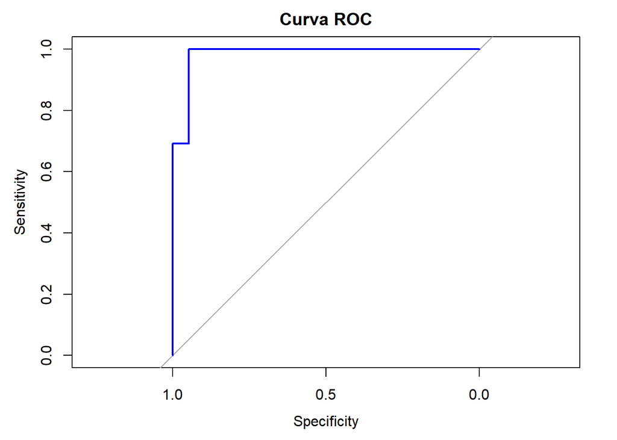

```r
# Graficar la curva ROC
plot(roc_obj, col = "blue", main = "Curva ROC")
```

```r
# Calcular el AUC
auc(roc_obj)
```

```
## Area under the curve: 0.9838
```

El **AUC** obtenido es de 0.9838, lo que indica que el modelo tiene un rendimiento de clasificación excelente.

## 4. Ejercicios Prácticos

### **Ejercicio 1**: Regresión logística binaria

Usa el conjunto de datos `iris` para predecir si una flor es de la especie `virginica` (1) o no (0) en función de las variables `Sepal.Length` y `Petal.Length`.

```r
# Crear la variable dependiente binaria
iris$virginica <- ifelse(iris$Species == "virginica", 1, 0)

# Ajustar el modelo de regresión logística
modelo_iris_logit <- glm(virginica ~ Sepal.Length + Petal.Length, data = iris, family = binomial)
# Mostrar el resumen del modelo
summary(modelo_iris_logit)
```

```
##
## Call:
## glm(formula = virginica ~ Sepal.Length + Petal.Length, family = binomial,
##     data = iris)
##
## Coefficients:
##              Estimate Std. Error z value Pr(>|z|)
## (Intercept)   -39.839     13.088  -3.044 0.002336 **
## Sepal.Length   -4.017      1.623  -2.474 0.013342 *
## Petal.Length   13.313      3.913   3.402 0.000668 ***
## ---
## Signif. codes:  0 '***' 0.001 '**' 0.01 '*' 0.05 '.' 0.1 ' ' 1
##
## (Dispersion parameter for binomial family taken to be 1)
##
##     Null deviance: 190.95  on 149  degrees of freedom
## Residual deviance:  23.85  on 147  degrees of freedom
## AIC: 29.85
##
## Number of Fisher Scoring iterations: 10
```

### **Ejercicio 2**: Evaluar el rendimiento del modelo

Construye la matriz de confusión y calcula el AUC para el modelo ajustado en `iris`.

```r
# Tu código aquí
```

**Mostrar solución**

```r
# Predecir las probabilidades
predicciones_iris <- predict(modelo_iris_logit, type = "response")

# Convertir probabilidades a clases (0 o 1)
pred_clases_iris <- ifelse(predicciones_iris > 0.5, 1, 0)

# Crear la matriz de confusión
table(Predicho = pred_clases_iris, Observado = iris$virginica)
```

```
##         Observado
## Predicho  0  1
##        0 97  2
##        1  3 48
```

```r
# Crear la curva ROC y calcular el AUC
roc_obj_iris <- roc(iris$virginica, predicciones_iris)
```

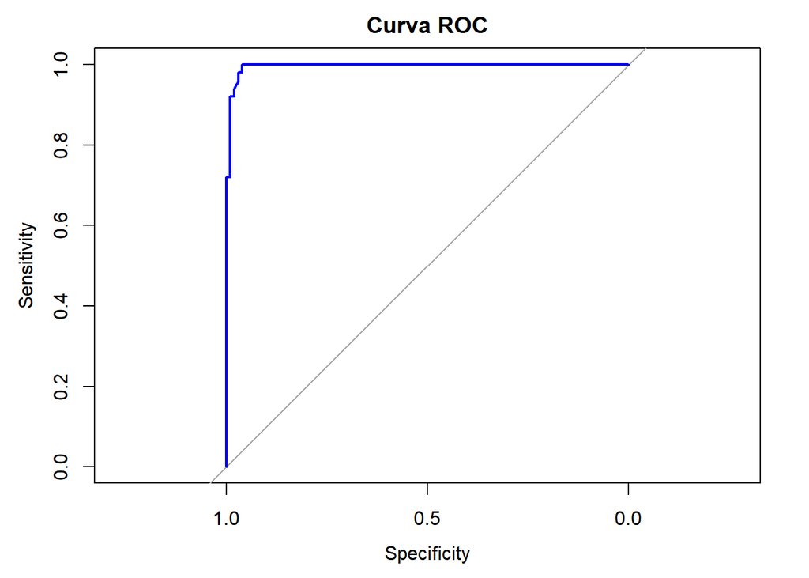

```r
plot(roc_obj_iris, col = "blue", main = "Curva ROC")
```

```r
auc(roc_obj_iris)
```

```
## Area under the curve: 0.9957
```